# DRAFT stock recovery analysis: WKREBUILD toolset

Iago MOSQUEIRA (WMR) <iago.mosqueira@wur.nl

08 March, 2023

# Installation

The code has required a number of extensions and modifications of code in various FLR packages. The simples way to install the required versions is to make use of the FLR R-universe repository, using the following command

```r
install.packages(c("FLCore", "FLasher", "ggplotFL", "mse", "mseviz"),
  repos=c(CRAN="https://cloud.r-project.org/",
  FLR="https://flr.r-universe.dev"))
```

# Operating model conditioning (data.R)

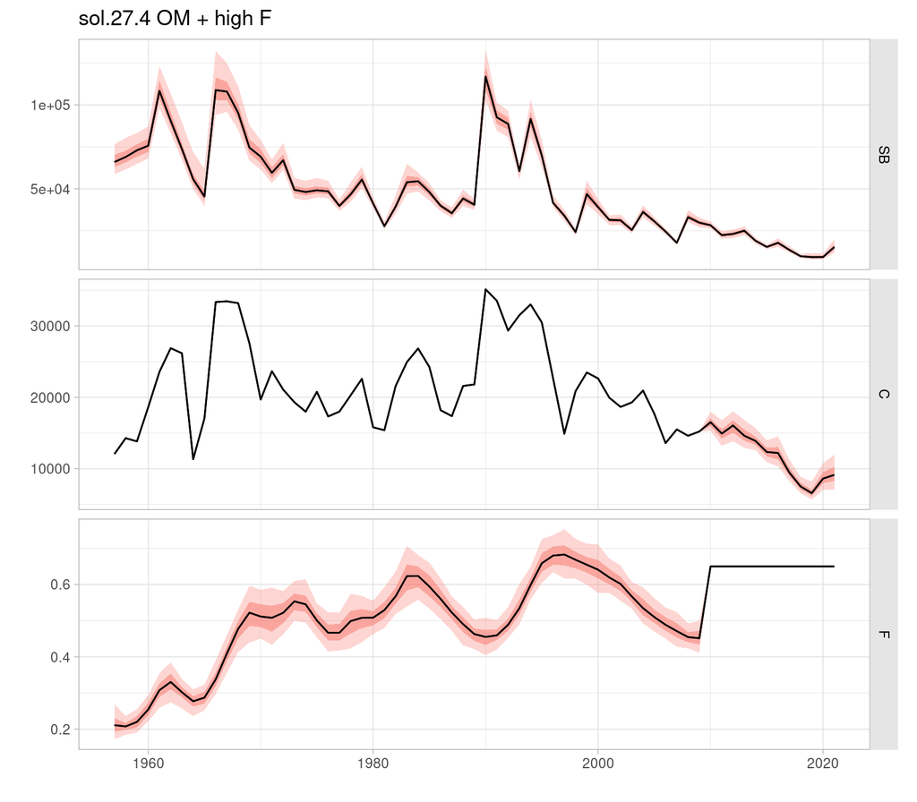

- A stock-recruitment relationship was fitted to all OM iterations. At the moment a segmented-regression SRR, with inflexion point fixed at $Blim$, was used, but work is ongoing to be able to combine SRRs with different functional forms.

```r
sgrg <- fmle(as.FLSR(stock, model="segreg"), fixed=list(b=icespts$Blim))
```

```r
om <- fwdWindow(om, end=fy)
```

```r
deviances(om)[, ac(2022:fy)] <- ar1rlnorm(rho=0.04, years=2022:fy,
  iter=500, meanlog=0, sdlog=0.4)
```

- An Observation Error Model is then set that contains past stock observations and adds future deviances in observations. In this case, lognormal errors in catch.n, with $sd=0.2$ were added.

```r
oem <- FLoem(
  observations=list(stk=stock(om)),
  deviances=list(stk=FLQuants(catch.n=rlnorm(500, catch.n(om) %=% 0, 0.2))),
  method=perfect.oem
)
```

# Evaluation of recovery rules (model.R)

- A simple evaluation of possible setups for a recovery rule can now be carried out. The MPs, as implemented in the ‘mse’ package, consist of three elements:
1. An estimation method (‘est’): a shortcut module substitutes the stock assessment method, with added deviances in the estimate of stock status (SSBdevs).
2. A Harvest Control Rule (‘hcr’): a hockeystick HCR with four variables (limit, minimum, target and trigger) is set up, using SSB as input and F as output.
3. An implementation system (‘isys’): this step implements the short-term forecast used to convert the target F into a TAC value to be used on the advice year. The method sets future biology and selectivity to match the recent (3 years) averages, computes past observed recruitment to obtain a geometric mean to apply in the projection, adds deviances to the fishing mortalities applied to the stock, and carries out the forecast to obtain the corresponding catch level. The intermediate year assumption is that of fishing mortality being equal to the last observed year, but the alternative assumption of catch equal to the set TAC could be added.
- The three steps are specified in a control structure, as follows:

```r
rule <- mpCtrl(list(
  # shortcut.sa + SSBdevs
  est = mseCtrl(method=shortcut.sa,
    args=list(SSBdevs=SSBdevs)),
  # hockeystick as ICES
  hcr = mseCtrl(method=hockeystick.hcr,
    args=list(lim=0, trigger=c(icespts$Btrigger), target=c(icespts$Fmsy), min=0,
    metric="ssb", output="fbar")),
  #
  isys = mseCtrl(method=tac.is,
    args=list(recyrs=30, fmin=0, Fdevs=Fdevs))
))
```

- For this specific application, a function is available that simplifies the process and uses standard ICES assumptions and names. For example the call below creates a control structure that implements the standard ICES advice rule using the operational points currently in use for sol.27.4, and some devainces in SSB and F previously constructed. The function is instructed to use all all recruitment estimates but the last two (`recyrs=-2`), in the forecast.

```r
sdevs <- shortcut_devs(om, Fcv=0.212, Fphi=0.423)

arule <- icesControl(SSBdevs=sdevs$SSB, Fdevs=sdevs$F,
  Btrigger=42838, Blim=0, Ftarget=0.207, Fmin=0, recyrs=-2)
```

- A plot of a particular hockeystick HCR can be obtained with an specific function

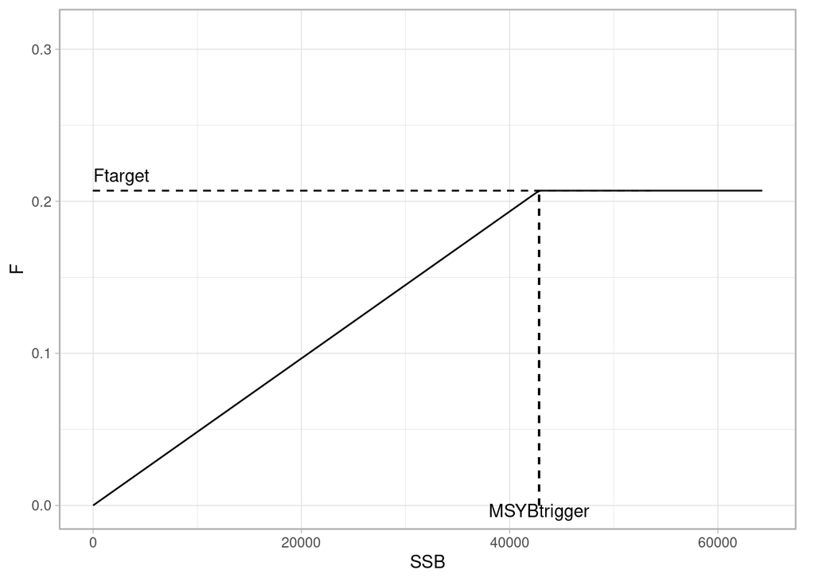

```r
plot_hockeystick.hcr(arule$hcr, labels=c(trigger="MSYBtrigger", limit="",
  min="", target="Ftarget")) + xlab("SSB") + ylab("F")
```

- Applying the MP specified by such a control structure requires a call to the ‘mp’ function with the OM, OEM and control objects. Only one extra argument is required, the starting year of the simulation (‘iy’). By default the simulation will run to the last year of the ‘om’ object, and on an annual basis.

```r
run <- mp(om, oem=oem, ctrl=arule, args=list(iy=2021))
```

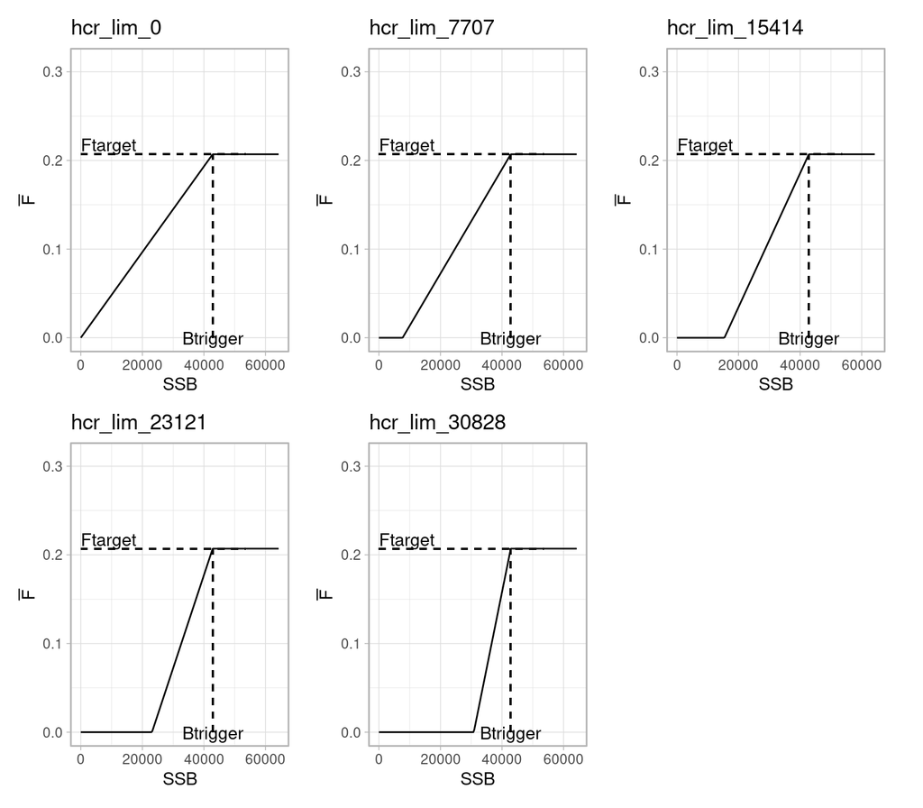

- To run these alternative MPs, the ‘mps’ function takes the same arguments as a call for a single MP, but also a list of alternative values for a HCR argument

```r
runs <- mps(om, oem=oem, ctrl=arule, args=mseargs,
  hcr=list(lim=seq(0, 30828, length=5)))
```

- If a parallel backend is available, as setup using any of those that work with the ‘foreach’ package, each scenario will be run on separate cores or nodes. The example above, executed over 5 cores on a laptop computer, took 3 minutes to finalise.
- To obtain a base line to evaluate the performance of these recovery MPs, a single forecast of the OM was carried out in which fishing is stopped, and recovery proceeds as quickly as possible

```r
runf0 <- fwd(om, control=fwdControl(year=2023:2042, quant="fbar", value=0))
```

- We can now compare the 5 MPs with the expected stock development if fishing was to stop (OM in the plot).

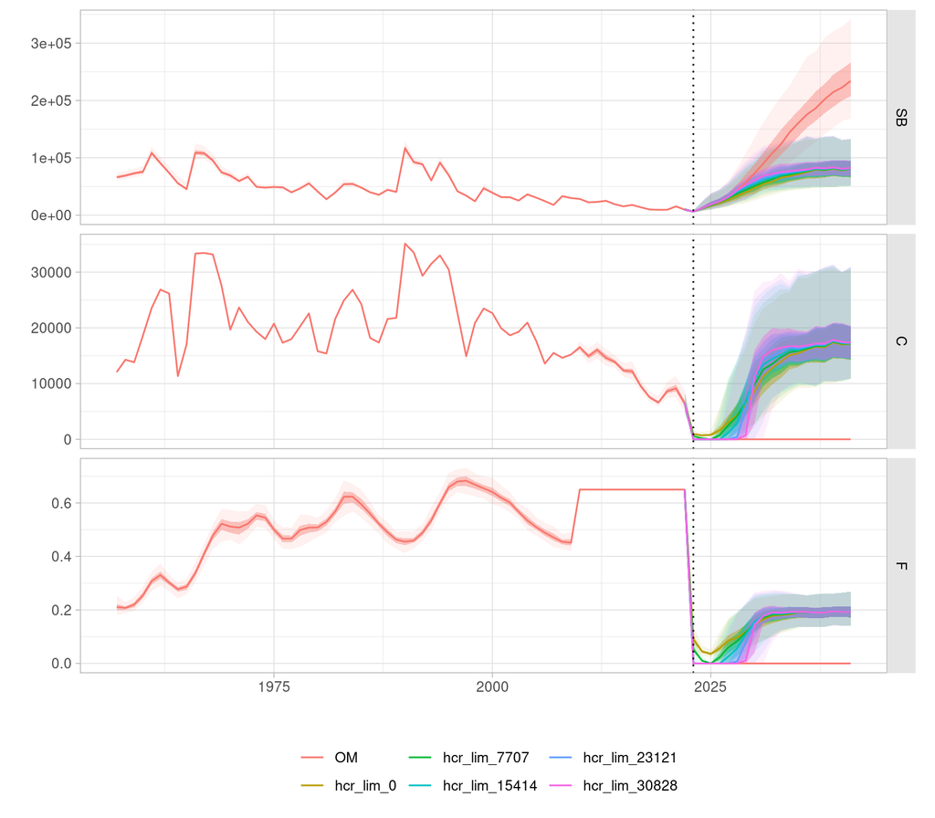

- A similar exercise was carried out with MPs in which the HCR also changed in the level at which fishing mortality will flatten as the stock declines, i.e. the minimum F is not 0.

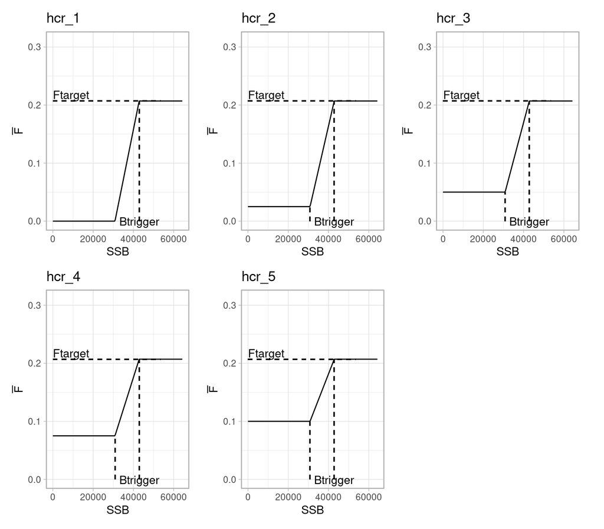

- The results are again compared with a zero fishing projection, but another one in which F is kept at some level, for example due to mixed fisheries catches, could be used instead. A simple call to ‘fwd’ with a ‘fbar’ target would provide that.

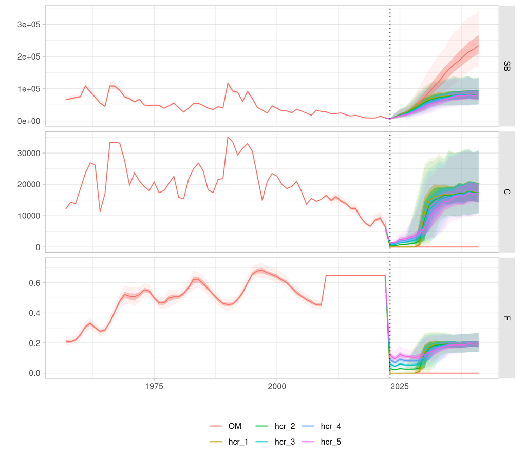

- The ‘hockeystick.hcr’ function is able to accommodate a large number of HCR shapes, but only if they can be specified using the four arguments listed above. Rules in which two target levels are chosen according to stock status, would require a new function, which would take little time to get ready if required.
- Other options or manners in which the short-term forecast is conducted, could also be incorporated to the ‘tac.isys’ function.